# Mixed Effects

Lisa DeBruine

Generate data for a Stroop task where people (`subjects`) say the colour of colour words (`stimuli`) shown in each of two versions (`congruent` and `incongruent`). Subjects are in one of two conditions (`hard` and `easy`). The dependent variable (`DV`) is reaction time.

We expect people to have faster reaction times for congruent stimuli than incongruent stimuli (main effect of version) and to be faster in the easy condition than the hard condition (main effect of condition). We’ll look at some different interaction patterns below.

## Setup

```r
library(tidyverse)   # for data wrangling, pipes, and good dataviz
library(afex)        # for mixed effect models
library(broom.mixed) # for getting tidy data tables from mixed models
library(faux)        # for simulating correlated variables

options(digits = 4, scipen = 10)
```

## Random intercepts

### Subjects

First, we need to generate a sample of subjects. Each subject will have slightly faster or slower reaction times on average; this is their random intercept (`sub_i`). We’ll model it from a normal distribution with a mean of 0 and SD of 100ms.

We also add between-subject variables here. Each subject is in only one condition, so assign half `easy` and half `hard`. Set the number of subjects as `sub_n` at the beginning so you can change this in the future with only one edit.

```r
sub_n  <- 20 # number of subjects in this simulation
sub_sd <- 100 # SD for the subjects' random intercept

sub <- tibble(
  sub_id = 1:sub_n,
  sub_i  = rnorm(sub_n, 0, sub_sd), # random intercept
  sub_cond = rep(c("easy","hard"), each = sub_n/2) # between-subjects factor
)
```

I like to check my simulations at every step with a graph. We expect subjects in `hard` and `easy` conditions to have approximately equal intercepts.

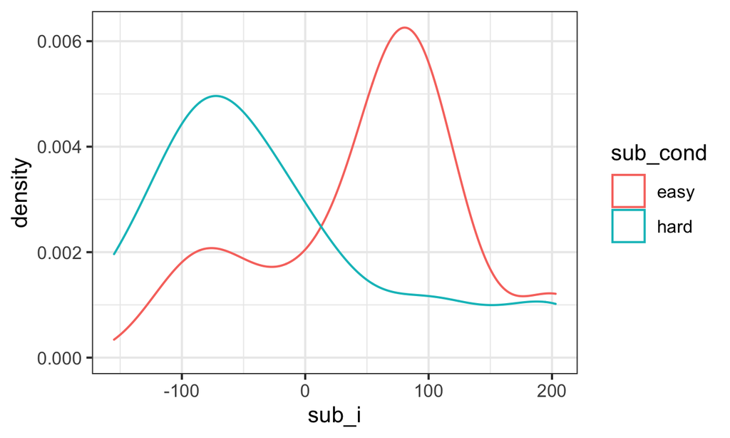

Double-check subject intercepts

```r
sub %>%
  ggplot(aes(sub_i, color = sub_cond)) +
  geom_density() +
  theme_bw()
```

### Stimuli

Now, we generate a sample of stimuli. Each stimulus will have slightly faster or slower reaction times on average; this is their random intercept (`stim_i`). We’ll model it from a normal distribution with a mean of 0 and SD of 50ms (it seems reasonable to expect less variability between words than people for this task). Stimulus version (`congruent` vs `incongruent`) is a within-stimulus variable, so we don’t need to add it here.

```r
stim_n  <- 50 # number of stimuli in this simulation
stim_sd <- 50 # SD for the stimuli's random intercept

stim <- tibble(
  stim_id = 1:stim_n,
  stim_i = rnorm(stim_n, 0, stim_sd) # random intercept
)
```

Plot the random intercepts to double-check they look like you expect.

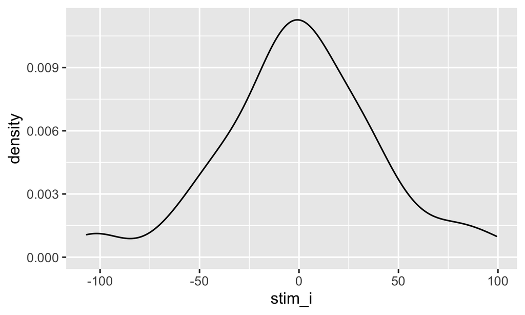

Double-check stimulus intercepts

```r
ggplot(stim, aes(stim_i)) +
  geom_density()
```

### Trials

Now we put the subjects and stimuli together. In this study, all subjects respond to all stimuli in both congruent and incongruent versions, but subjects are in only one condition. The function `crossing` gives you a data frame with all possible combinations of the arguments. Add the data specific to each subject and stimulus by left joining the `sub` and `stim` data frames.

```r
trials <- crossing(
  sub_id = sub$sub_id, # get subject IDs from the sub data table
  stim_id = stim$stim_id, # get stimulus IDs from the stim data table
  stim_version = c("congruent", "incongruent") # all subjects see both congruent and incongruent versions of all stimuli
) %>%
  left_join(sub, by = "sub_id") %>% # includes the intercept and conditin for each subject
  left_join(stim, by = "stim_id")   # includes the intercept for each stimulus
```

## Calculate DV

Now we can calculate the DV by adding together an overall intercept (mean RT for all trials), the subject-specific intercept, the stimulus-specific intercept, the effect of subject condition, the interaction between condition and version (set to 0 for this first example), the effect of stimulus version, and an error term.

### Fixed effects

We set these effects in raw units (ms) and effect-code the subject condition and stimulus version. It’s usually easiest to interpret if you recode the level that you predict will be larger as +0.5 and the level you predict will be smaller as -0.5. So when we set the effect of subject condition (`sub_cond_eff`) to 50, that means the average difference between the easy and hard condition is 50ms. `Easy` is effect-coded as -0.5 and `hard` is effect-coded as +0.5, which means that trials in the easy condition have -0.5 * 50ms (i.e., -25ms) added to their reaction time, while trials in the hard condition have +0.5 * 50ms (i.e., +25ms) added to their reaction time.

```r
# set variables to use in calculations below
grand_i          <- 400 # overall mean DV
sub_cond_eff     <- 50  # mean difference between conditions: hard - easy
stim_version_eff <- 50  # mean difference between versions: incongruent - congruent
cond_version_ixn <-  0  # interaction between version and condition
error_sd         <- 25  # residual (error) SD
```

The code chunk below effect-codes the condition and version factors (important for the analysis below), generates an error term for each trial, and generates the DV.

```r
conditions <- c("easy" = -0.5, "hard" = +0.5)
versions   <- c("congruent" = -0.5, "incongruent" = +0.5)

dat <- trials %>%
  mutate(
    # effect-code subject condition and stimulus version
    sub_cond.e = recode(sub_cond, !!!conditions),
    stim_version.e = recode(stim_version, !!!versions),
    # calculate error term (normally distributed residual with SD set above)
    err = rnorm(nrow(.), 0, error_sd),
    # calculate DV from intercepts, effects, and error
    dv = grand_i + sub_i + stim_i + err +
         (sub_cond.e * sub_cond_eff) +
         (stim_version.e * stim_version_eff) +
         (sub_cond.e * stim_version.e * cond_version_ixn) # in this example, this is always 0 and could be omitted
  )
```

As always, graph to make sure you’ve simulated the general pattern you expected.

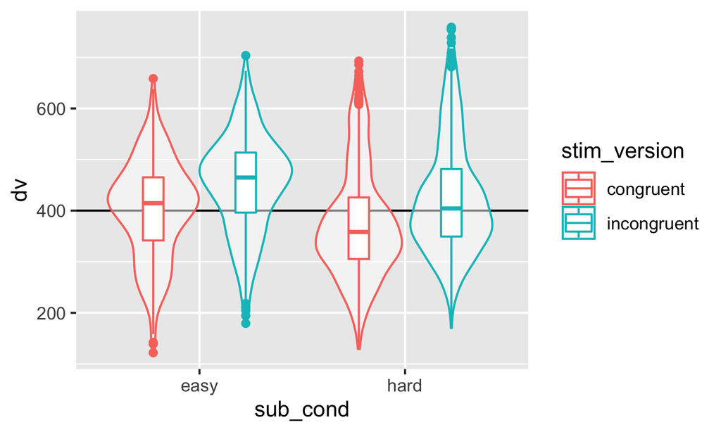

Double-check the simulated pattern

```r
ggplot(dat, aes(sub_cond, dv, color = stim_version)) +
  geom_hline(yintercept = grand_i) +
  geom_violin(alpha = 0.5) +
  geom_boxplot(width = 0.2, position = position_dodge(width = 0.9))
```

### Interactions

```r
# set variables to use in calculations below
grand_i    <- 400
hard_congr <- -25
hard_incon <- +25
easy_congr <- -50
easy_incon <- +50
error_sd   <-  25

conditions <- c("easy" = -0.5, "hard" = +0.5)
versions   <- c("congruent" = -0.5, "incongruent" = +0.5)
```

Use the code below to transform the simple main effects above into main effects and interactions for use in the equations below.

```r
# calculate main effects and interactions from simple effects above

# mean difference between easy and hard conditions
sub_cond_eff     <- (easy_congr + easy_incon)/2 -
                    (hard_congr + hard_incon)/2
# mean difference between incongruent and congruent versions
stim_version_eff <- (hard_incon + easy_incon)/2 -
                    (hard_congr + easy_congr)/2
# interaction between version and condition
cond_version_ixn <- (easy_incon - easy_congr) -
                    (hard_incon - hard_congr)
```

Then generate the DV the same way we did above, but also add the interaction effect multiplied by the effect-coded subject condition and stimulus version.

```r
dat <- trials %>%
  mutate(
    # effect-code subject condition and stimulus version
    sub_cond.e = recode(sub_cond, !!!conditions),
    stim_version.e = recode(stim_version, !!!versions),
    # calculate error term (normally distributed residual with SD set above)
    err = rnorm(nrow(.), 0, error_sd),
    # calculate DV from intercepts, effects, and error
    dv = grand_i + sub_i + stim_i + err +
         (sub_cond.e * sub_cond_eff) +
         (stim_version.e * stim_version_eff) +
         (sub_cond.e * stim_version.e * cond_version_ixn)
  )
```

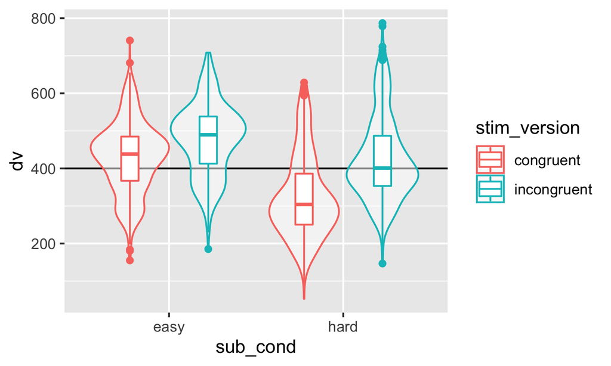

Double-check the interaction between condition and version

```r
ggplot(dat, aes(sub_cond, dv, color = stim_version)) +
  geom_hline(yintercept = grand_i) +
  geom_violin(alpha = 0.5) +
  geom_boxplot(width = 0.2, position = position_dodge(width = 0.9))
```

```r
dat %>%
  group_by(sub_cond, stim_version) %>%
  summarise(m = mean(dv) - grand_i %>% round(1),
            .groups = "drop") %>%
  pivot_wider(names_from = "stim_version", values_from = "m")
```

| sub_cond | congruent | incongruent |
| --- | --- | --- |
| easy | 29.16 | 77.95 |
| hard | -75.07 | 26.32 |

## Analysis

New we will run a linear mixed effects model with `lmer` and look at the summary.

```r
mod <- lmer(dv ~ sub_cond.e * stim_version.e +
              (1 | sub_id) +
              (1 | stim_id),
            data = dat)

mod.sum <- summary(mod)

mod.sum
## Linear mixed model fit by REML. t-tests use Satterthwaite's method [
## lmerModLmerTest]
## Formula: dv ~ sub_cond.e * stim_version.e + (1 | sub_id) + (1 | stim_id)
##    Data: dat
##
## REML criterion at convergence: 18891
##
## Scaled residuals:
##    Min     1Q Median     3Q    Max
## -2.976 -0.658 -0.005  0.672  3.804
##
## Random effects:
##  Groups   Name        Variance Std.Dev.
##  stim_id  (Intercept) 1646     40.6
##  sub_id   (Intercept) 9271     96.3
##  Residual              623     25.0
## Number of obs: 2000, groups:  stim_id, 50; sub_id, 20
##
## Fixed effects:
##                           Estimate Std. Error      df t value          Pr(>|t|)
## (Intercept)                 414.59      22.29   20.61   18.60 0.000000000000023
## sub_cond.e                  -77.93      43.07   18.00   -1.81             0.087
## stim_version.e               75.09       1.12 1929.00   67.30           < 2e-16
## sub_cond.e:stim_version.e    52.60       2.23 1929.00   23.57           < 2e-16
##
## (Intercept)               ***
## sub_cond.e                .
## stim_version.e            ***
## sub_cond.e:stim_version.e ***
## ---
## Signif. codes:  0 '***' 0.001 '**' 0.01 '*' 0.05 '.' 0.1 ' ' 1
##
## Correlation of Fixed Effects:
##             (Intr) sb_cn. stm_v.
## sub_cond.e  0.000
## stim_versn. 0.000  0.000
## sb_cnd.:s_. 0.000  0.000  0.000
```

### Sense checks

First, check that your groups make sense.

- The number of obs should be the total number of trials analysed.
- `sub_id` should be what we set `sub_n` to above.
- `stim_id` should be what we set `stim_n` to above.

```r
mod.sum$ngrps
## stim_id  sub_id
##      50      20
```

Next, look at the random effects.

- The SD for `sub_id` should be near `sub_sd`.
- The SD for `stim_id` should be near `stim_sd`.
- The residual SD should be near `error_sd`.

```r
mod.sum$varcor
```

```
##  Groups   Name        Std.Dev.
##  stim_id  (Intercept) 40.6
##  sub_id   (Intercept) 96.3
##  Residual             25.0
```

Finally, look at the fixed effects.

- The estimate for the Intercept should be near the `grand_i`.
- The main effect of `sub_cond.e` should be near what we calculated for `sub_cond_eff`.
- The main effect of `stim_version.e` should be near what we calculated for `stim_version_eff`.
- The interaction between `sub_cond.e`:`stim_version.e` should be near what we calculated for `cond_version_ixn`.

```r
mod.sum$coefficients
```

```
##                           Estimate Std. Error      df t value   Pr(>|t|)
## (Intercept)                 414.59     22.289   20.61  18.601  2.344e-14
## sub_cond.e                  -77.93     43.075   18.00  -1.809  8.716e-02
## stim_version.e               75.09      1.116 1929.00  67.297  0.000e+00
## sub_cond.e:stim_version.e    52.60      2.232 1929.00  23.571 3.651e-108
```

### Random effects

Plot the subject intercepts from our code above (`sub$sub_i`) against the subject intercepts calculcated by `lmer` (`ranef(mod)$sub_id`).

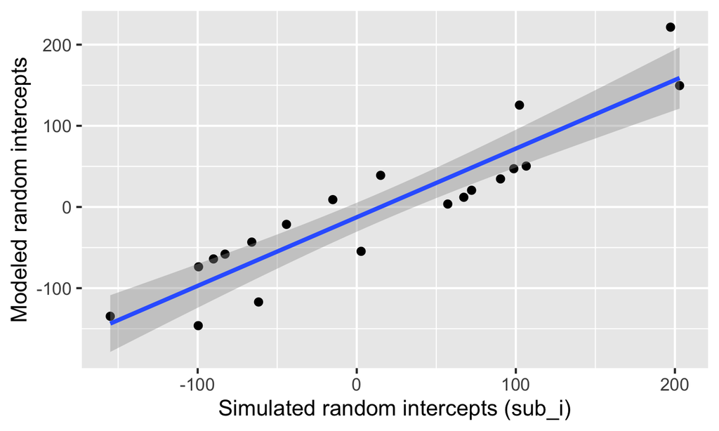

Compare simulated subject random intercepts to those from the model

```r
ranef(mod)$sub_id %>%
  as_tibble(rownames = "sub_id") %>%
  rename(mod_sub_i = `(Intercept)`) %>%
  mutate(sub_id = as.integer(sub_id)) %>%
  left_join(sub, by = "sub_id") %>%
  ggplot(aes(sub_i,mod_sub_i)) +
  geom_point() +
  geom_smooth(method = "lm") +
  xlab("Simulated random intercepts (sub_i)") +
  ylab("Modeled random intercepts")
## `geom_smooth()` using formula 'y ~ x'
```

Plot the stimulus intercepts from our code above (`stim$stim_i`) against the stimulus intercepts calculcated by `lmer` (`ranef(mod)$stim_id`).

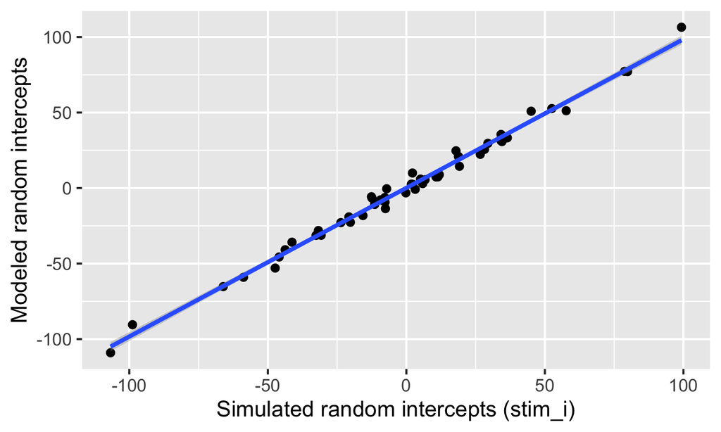

Compare simulated stimulus random intercepts to those from the model

```r
ranef(mod)$stim_id %>%
  as_tibble(rownames = "stim_id") %>%
  rename(mod_stim_i = `(Intercept)`) %>%
  mutate(stim_id = as.integer(stim_id)) %>%
  left_join(stim, by = "stim_id") %>%
  ggplot(aes(stim_i,mod_stim_i)) +
  geom_point() +
  geom_smooth(method = "lm") +
  xlab("Simulated random intercepts (stim_i)") +
  ylab("Modeled random intercepts")
## `geom_smooth()` using formula 'y ~ x'
```

## Function

```r
sim_lmer <- function( sub_n = 200,
                      sub_sd = 100,
                      stim_n = 50,
                      stim_sd = 50,
                      grand_i = 400,
                      sub_cond_eff = 0,
                      stim_version_eff = 0,
                      cond_version_ixn = 0,
                      error_sd = 25) {
  sub <- tibble(
    sub_id = 1:sub_n,
    sub_i  = rnorm(sub_n, 0, sub_sd),
    sub_cond = rep(c("hard","easy"), each = sub_n/2)
  )

  stim <- tibble(
    stim_id = 1:stim_n,
    stim_i = rnorm(stim_n, 0, stim_sd)
  )

  conditions <- c("easy" = -0.5, "hard" = +0.5)
  versions   <- c("congruent" = -0.5, "incongruent" = +0.5)

  dat <- crossing(
    sub_id = sub$sub_id,
    stim_id = stim$stim_id,
    stim_version = c("congruent", "incongruent")
  ) %>%
    left_join(sub, by = "sub_id") %>%
    left_join(stim, by = "stim_id") %>%
    mutate(
      # effect-code subject condition and stimulus version
      sub_cond.e = recode(sub_cond, !!!conditions),
      stim_version.e = recode(stim_version, !!!versions),
      # calculate error term (normally distributed residual with SD set above)
      err = rnorm(nrow(.), 0, error_sd),
      # calculate DV from intercepts, effects, and error
      dv = grand_i + sub_i + stim_i + err +
           (sub_cond.e * sub_cond_eff) +
           (stim_version.e * stim_version_eff) +
           (sub_cond.e * stim_version.e * cond_version_ixn)
    )

  mod <- lmer(dv ~ sub_cond.e * stim_version.e +
                (1 | sub_id) +
                (1 | stim_id),
              data = dat)

  return(mod)
}
```

Run the function with the default values (so all fixed effects set to 0).

```r
sim_lmer() %>% summary()
## Linear mixed model fit by REML. t-tests use Satterthwaite's method [
## lmerModLmerTest]
## Formula: dv ~ sub_cond.e * stim_version.e + (1 | sub_id) + (1 | stim_id)
##    Data: dat
##
## REML criterion at convergence: 187198
##
## Scaled residuals:
##    Min     1Q Median     3Q    Max
## -4.234 -0.669 -0.007  0.669  3.696
##
## Random effects:
##  Groups   Name        Variance Std.Dev.
##  sub_id   (Intercept) 10901    104.4
##  stim_id  (Intercept)  2596     51.0
##  Residual               620     24.9
## Number of obs: 20000, groups:  sub_id, 200; stim_id, 50
##
## Fixed effects:
##                            Estimate Std. Error        df t value Pr(>|t|)
## (Intercept)                 408.528     10.318   161.666   39.59   <2e-16 ***
## sub_cond.e                  -30.425     14.770   198.000   -2.06    0.041 *
## stim_version.e               -0.476      0.352 19749.000   -1.35    0.176
## sub_cond.e:stim_version.e    -0.243      0.704 19749.000   -0.35    0.730
## ---
## Signif. codes:  0 '***' 0.001 '**' 0.01 '*' 0.05 '.' 0.1 ' ' 1
##
## Correlation of Fixed Effects:
##             (Intr) sb_cn. stm_v.
## sub_cond.e  0.000
## stim_versn. 0.000  0.000
## sb_cnd.:s_. 0.000  0.000  0.000
```

Try changing some variables to simulate different patterns of fixed effects.

```r
sim_lmer(sub_cond_eff = 0,
         stim_version_eff = 75,
         cond_version_ixn = 50) %>%
  summary()
## Linear mixed model fit by REML. t-tests use Satterthwaite's method [
## lmerModLmerTest]
## Formula: dv ~ sub_cond.e * stim_version.e + (1 | sub_id) + (1 | stim_id)
##    Data: dat
##
## REML criterion at convergence: 187589
##
## Scaled residuals:
##    Min     1Q Median     3Q    Max
## -3.828 -0.666  0.004  0.662  3.763
##
## Random effects:
##  Groups   Name        Variance Std.Dev.
##  sub_id   (Intercept) 10852    104.2
##  stim_id  (Intercept)  2434     49.3
##  Residual               633     25.2
## Number of obs: 20000, groups:  sub_id, 200; stim_id, 50
##
## Fixed effects:
##                            Estimate Std. Error        df t value Pr(>|t|)
## (Intercept)                 398.955     10.147   167.478    39.3   <2e-16 ***
## sub_cond.e                   -7.434     14.737   198.000    -0.5     0.61
## stim_version.e               75.135      0.356 19749.000   211.2   <2e-16 ***
## sub_cond.e:stim_version.e    50.647      0.711 19749.000    71.2   <2e-16 ***
## ---
## Signif. codes:  0 '***' 0.001 '**' 0.01 '*' 0.05 '.' 0.1 ' ' 1
##
## Correlation of Fixed Effects:
##             (Intr) sb_cn. stm_v.
## sub_cond.e  0.000
## stim_versn. 0.000  0.000
## sb_cnd.:s_. 0.000  0.000  0.000
```

### Power analysis

First, wrap your simulation function inside of another function that takes the argument of a replication number, runs a simulated analysis, and returns a data table of the fixed and random effects (made with `broom.mixed::tidy()`). You can use purrr’s `map_df()` function to create a data table of results from multiple replications of this function. We’re only running 10 replications here in the interests of time, but you’ll want to run 100 or more for a proper power calcuation.

```r
sim_lmer_pwr <- function(rep) {
  s <- sim_lmer(sub_cond_eff = 0,
                stim_version_eff = 75,
                cond_version_ixn = 50)

  # put just the fixed effects into a data table
  broom.mixed::tidy(s, "fixed") %>%
    mutate(rep = rep) # add a column for which rep
}

my_power <- map_df(1:10, sim_lmer_pwr)
```

You can then plot the distribution of estimates across your simulations.

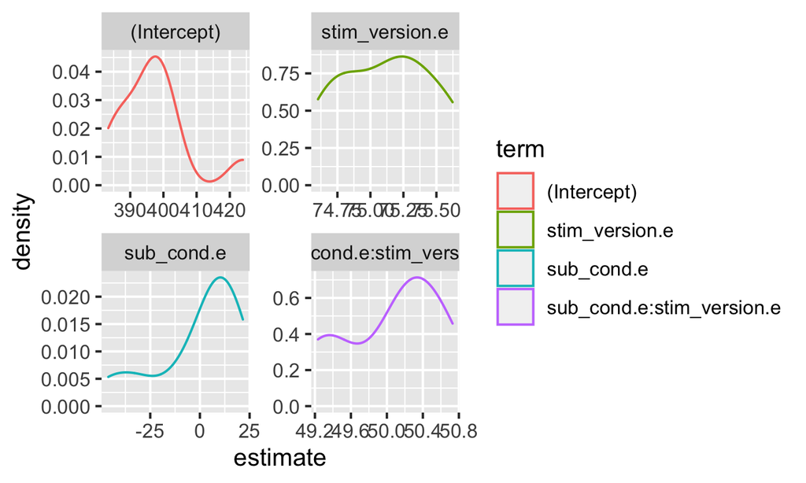

```r
my_power %>%
  ggplot(aes(estimate, color = term)) +
  geom_density() +
  facet_wrap(~term, scales = "free")
```

You can also just calculate power as the proportion of p-values less than your alpha.

```r
my_power %>%
  group_by(term) %>%
  summarise(power = mean(p.value < 0.05),
            .groups = "drop")
```

| term | power |
| --- | --- |
| (Intercept) | 1.0 |
| stim_version.e | 1.0 |
| sub_cond.e | 0.2 |
| sub_cond.e:stim_version.e | 1.0 |

## Random slopes

In the example so far we’ve ignored random variation among subjects or stimuli in the size of the fixed effects (i.e., **random slopes**).

First, let’s reset the parameters we set above.

```r
sub_n            <- 200 # number of subjects in this simulation
sub_sd           <- 100 # SD for the subjects' random intercept
stim_n           <- 50  # number of stimuli in this simulation
stim_sd          <- 50  # SD for the stimuli's random intercept
grand_i          <- 400 # overall mean DV
sub_cond_eff     <- 50  # mean difference between conditions: hard - easy
stim_version_eff <- 50  # mean difference between versions: incongruent - congruent
cond_version_ixn <-  0  # interaction between version and condition
error_sd         <- 25  # residual (error) SD
```

### Subjects

In addition to generating a random intercept for each subject, now we will also generate a random slope for any within-subject factors. The only within-subject factor in this design is `stim_version`. The main effect of `stim_version` is set to 50 above, but different subjects will show variation in the size of this effect. That’s what the random slope captures. We’ll set `sub_version_sd` below to the SD of this variation and use this to calculate the random slope (`sub_version_slope`) for each subject.

The code below creates two variables (`sub_i`, `sub_version_slope`) that are correlated with r = -0.2, means of 0, and SDs equal to what we set `sub_sd` above and `sub_version_sd` below.

```r
sub_version_sd <- 20
sub_i_version_cor <- -0.2

sub <- faux::rnorm_multi(
  n = sub_n,
  r = sub_i_version_cor,
  mu = 0, # means of random intercepts and slopes are always 0
  sd = c(sub_sd, sub_version_sd),
  varnames = c("sub_i", "sub_version_slope")
) %>%
  mutate(
    sub_id = 1:sub_n,
    sub_cond = rep(c("easy","hard"), each = sub_n/2) # between-subjects factor
  )
```

Plot to double-check it looks sensible.

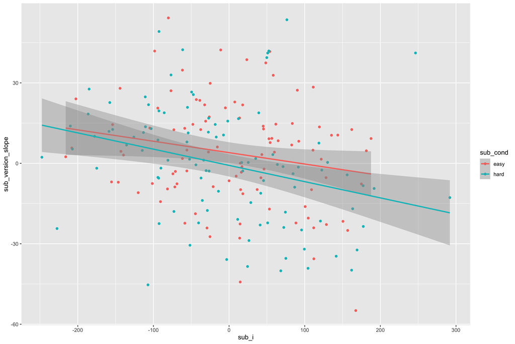

Double-check slope-intercept correlations

```r
ggplot(sub, aes(sub_i, sub_version_slope, color = sub_cond)) +
  geom_point() +
  geom_smooth(method = lm, formula = y~x)
```

### Stimuli

In addition to generating a random intercept for each stimulus, we will also generate a random slope for any within-stimulus factors. Both `stim_version` and `sub_condition` are within-stimulus factors (i.e., all stimuli are seen in both `congruent` and `incongruent` versions and both `easy` and `hard` conditions). So the main effects of version and condition (and their interaction) will vary depending on the stimulus.

They will also be correlated, but in a more complex way than above. You need to set the correlations for all pairs of slopes and intercept. Let’s set the correlation between the random intercept and each of the slopes to -0.4 and the slopes all correlate with each other +0.2 (You could set each of the six correlations separately if you want, though).

```r
stim_version_sd <- 10 # SD for the stimuli's random slope for stim_version
stim_cond_sd <- 30 # SD for the stimuli's random slope for sub_cond
stim_cond_version_sd <- 15 # SD for the stimuli's random slope for sub_cond:stim_version
stim_i_cor <- -0.4 # correlations between intercept and slopes
stim_s_cor <- +0.2 # correlations among slopes

# specify correlations for rnorm_multi (one of several methods)
stim_cors <- c(stim_i_cor, stim_i_cor, stim_i_cor,
                           stim_s_cor, stim_s_cor,
                                       stim_s_cor)
stim <- rnorm_multi(
  n = stim_n,
  r = stim_cors,
  mu = 0, # means of random intercepts and slopes are always 0
  sd = c(stim_sd, stim_version_sd, stim_cond_sd, stim_cond_version_sd),
  varnames = c("stim_i", "stim_version_slope", "stim_cond_slope", "stim_cond_version_slope")
) %>%
  mutate(
    stim_id = 1:stim_n
  )
```

Check your stimulated data using faux’s `check_sim_stats()` function. Here, we’re simulating different SDs for different effects, so our summary table should reflect this.

```r
select(stim, -stim_id) %>% # remove id
  check_sim_stats() %>%    # calculates means, SDs and correlations
  rename(i = 3, v = 4, c = 5, cv = 6) # rename columns to fit width
```

| n | var | i | v | c | cv | mean | sd |
| --- | --- | --- | --- | --- | --- | --- | --- |
| 50 | stim_cond_slope | -0.41 | 0.24 | 1.00 | 0.26 | 3.81 | 30.88 |
| 50 | stim_cond_version_slope | -0.39 | 0.03 | 0.26 | 1.00 | -0.69 | 14.58 |
| 50 | stim_i | 1.00 | -0.43 | -0.41 | -0.39 | 8.33 | 52.32 |
| 50 | stim_version_slope | -0.43 | 1.00 | 0.24 | 0.03 | -2.35 | 10.05 |

### Trials

Now we put the subjects and stimuli together in the same way as before.

```r
trials <- crossing(
  sub_id = sub$sub_id, # get subject IDs from the sub data table
  stim_id = stim$stim_id, # get stimulus IDs from the stim data table
  stim_version = c("congruent", "incongruent") # all subjects see both congruent and incongruent versions of all stimuli
) %>%
  left_join(sub, by = "sub_id") %>% # includes the intercept, slope, and conditin for each subject
  left_join(stim, by = "stim_id")   # includes the intercept and slopes for each stimulus
```

## Calculate DV

```r
conditions <- c("easy" = -0.5, "hard" = +0.5)
versions <- c("congruent" = -0.5, "incongruent" = +0.5)

dat <- trials %>%
  mutate(
    # effect-code subject condition and stimulus version
    sub_cond.e = recode(sub_cond, !!!conditions),
    stim_version.e = recode(stim_version, !!!versions),
    # calculate trial-specific effects by adding overall effects and slopes
    cond_eff = sub_cond_eff + stim_cond_slope,
    version_eff = stim_version_eff + stim_version_slope + sub_version_slope,
    cond_version_eff = cond_version_ixn + stim_cond_version_slope,
    # calculate error term (normally distributed residual with SD set above)
    err = rnorm(nrow(.), 0, error_sd),
    # calculate DV from intercepts, effects, and error
    dv = grand_i + sub_i + stim_i + err +
         (sub_cond.e * cond_eff) +
         (stim_version.e * version_eff) +
         (sub_cond.e * stim_version.e * cond_version_eff)
  )
```

As always, graph to make sure you’ve simulated the general pattern you expected.

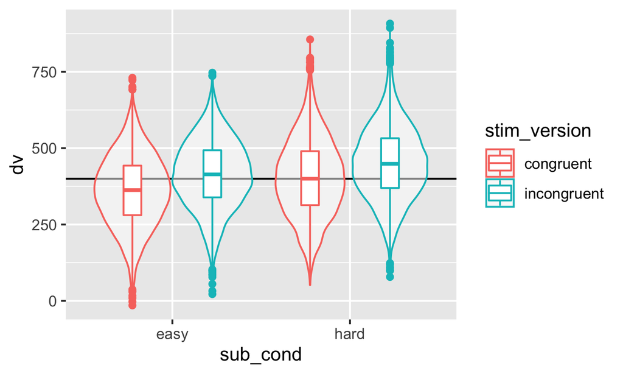

Double-check the simulated pattern

```r
ggplot(dat, aes(sub_cond, dv, color = stim_version)) +
  geom_hline(yintercept = grand_i) +
  geom_violin(alpha = 0.5) +
  geom_boxplot(width = 0.2, position = position_dodge(width = 0.9))
```

## Analysis

This model will take a lot longer to run than one without random slopes specified. This might be a good time for a coffee break.

```r
mod <- lmer(dv ~ sub_cond.e * stim_version.e +
              (1 + stim_version.e || sub_id) +
              (1 + stim_version.e*sub_cond.e || stim_id),
            data = dat)

mod.sum <- summary(mod)

mod.sum
## Linear mixed model fit by REML. t-tests use Satterthwaite's method [
## lmerModLmerTest]
## Formula: dv ~ sub_cond.e * stim_version.e + (1 + stim_version.e || sub_id) +
##     (1 + stim_version.e * sub_cond.e || stim_id)
##    Data: dat
##
## REML criterion at convergence: 188674
##
## Scaled residuals:
##    Min     1Q Median     3Q    Max
## -3.884 -0.670  0.005  0.669  3.923
##
## Random effects:
##  Groups    Name                      Variance Std.Dev.
##  sub_id    (Intercept)               10394    101.95
##  sub_id.1  stim_version.e              400     20.01
##  stim_id   (Intercept)                2744     52.39
##  stim_id.1 stim_version.e               99      9.95
##  stim_id.2 sub_cond.e                  960     30.99
##  stim_id.3 stim_version.e:sub_cond.e   197     14.02
##  Residual                              634     25.18
## Number of obs: 20000, groups:  sub_id, 200; stim_id, 50
##
## Fixed effects:
##                           Estimate Std. Error     df t value Pr(>|t|)
## (Intercept)                 407.32      10.34 151.91   39.40   <2e-16 ***
## sub_cond.e                   39.53      15.07 228.29    2.62   0.0093 **
## stim_version.e               50.04       2.03 148.76   24.68   <2e-16 ***
## sub_cond.e:stim_version.e    -4.21       3.53 201.61   -1.19   0.2340
## ---
## Signif. codes:  0 '***' 0.001 '**' 0.01 '*' 0.05 '.' 0.1 ' ' 1
##
## Correlation of Fixed Effects:
##             (Intr) sb_cn. stm_v.
## sub_cond.e  0.000
## stim_versn. 0.000  0.000
## sb_cnd.:s_. 0.000  0.000  0.000
```

### Sense checks

First, check that your groups make sense.

- `sub_id` = `sub_n` (200)
- `stim_id` = `stim_n` (50)

```r
mod.sum$ngrps
```

```
##  sub_id stim_id
##     200      50
```

Next, look at the SDs for the random effects.

- Group:`sub_id`
  - `(Intercept)` ~= `sub_sd`
  - `stim_version.e` ~= `sub_version_sd`
- Group: `stim_id`
  - `(Intercept)` ~= `stim_sd`
  - `stim_version.e` ~= `stim_version_sd`
  - `sub_cond.e` ~= `stim_cond_sd`
  - `stim_version.e:sub_cond.e` ~= `stim_cond_version_sd`
- Residual ~= `error_sd`

```r
mod.sum$varcor
```

```
##  Groups    Name                      Std.Dev.
##  sub_id    (Intercept)               101.95
##  sub_id.1  stim_version.e             20.01
##  stim_id   (Intercept)                52.39
##  stim_id.1 stim_version.e              9.95
##  stim_id.2 sub_cond.e                 30.99
##  stim_id.3 stim_version.e:sub_cond.e  14.02
##  Residual                             25.18
```

Finally, look at the fixed effects.

- `(Intercept)` ~= `grand_i`
- `sub_cond.e` ~= `sub_cond_eff`
- `stim_version.e` ~= `stim_version_eff`
- `sub_cond.e`:`stim_version.e` ~= `cond_version_ixn`

```r
mod.sum$coefficients
```

```
##                           Estimate Std. Error    df t value  Pr(>|t|)
## (Intercept)                407.325     10.339 151.9  39.398 1.210e-81
## sub_cond.e                  39.529     15.074 228.3   2.622 9.320e-03
## stim_version.e              50.041      2.027 148.8  24.684 1.814e-54
## sub_cond.e:stim_version.e   -4.212      3.528 201.6  -1.194 2.340e-01
```

### Random effects

Compare the subject intercepts and slopes from our code above (`sub$sub_i`) against the subject intercepts and slopes calculcated by `lmer` (`ranef(mod)$sub_id`).

```r
ranef(mod)$sub_id %>%
  as_tibble(rownames = "sub_id") %>%
  rename(mod_i = `(Intercept)`,
         mod_version_slope = stim_version.e) %>%
  mutate(sub_id = as.integer(sub_id)) %>%
  left_join(sub, by = "sub_id") %>%
  select(mod_i, sub_i,
         mod_version_slope,  sub_version_slope) %>%
  get_params() %>%    # calculates means, SDs and correlations
  rename(mod_v = 5, sub_v = 6) %>% # rename columns to fit width
  select(n, var, mod_i, mod_v, sub_i, sub_v, mean, sd)
```

| n | var | mod_i | mod_v | sub_i | sub_v | mean | sd |
| --- | --- | --- | --- | --- | --- | --- | --- |
| 200 | mod_i | 1.00 | -0.25 | 1.00 | -0.26 | 0.00 | 101.67 |
| 200 | mod_version_slope | -0.25 | 1.00 | -0.25 | 0.97 | 0.00 | 19.36 |
| 200 | sub_i | 1.00 | -0.25 | 1.00 | -0.25 | -0.93 | 101.82 |
| 200 | sub_version_slope | -0.26 | 0.97 | -0.25 | 1.00 | 1.72 | 20.86 |

Compare the stimulus intercepts and slopes from our code above (`stim$stim_i`) against the stimulus intercepts and slopes calculated by `lmer` (`ranef(mod)$stim_id`).

```r
x <- ranef(mod)$stim_id %>%
  as_tibble(rownames = "stim_id") %>%
  rename(mod_i = `(Intercept)`,
         mod_version_slope = stim_version.e,
         mod_cond_slope = sub_cond.e,
         mod_cond_version_slope = `stim_version.e:sub_cond.e`) %>%
  mutate(stim_id = as.integer(stim_id)) %>%
  left_join(stim, by = "stim_id") %>%
  select(mod_i, stim_i,
         mod_version_slope, stim_version_slope,
         mod_cond_slope, stim_cond_slope,
         mod_cond_version_slope, stim_cond_version_slope) %>%
  get_params()    # calculates means, SDs and correlations

nm <- names(x)[3:10]
x$var <- factor(x$var, levels = nm)
x %>%
  arrange(var) %>%
  rename(mod_v = 5, stim_v = 6,
         mod_c = 7, stim_c = 8,
         mod_cv = 9, stim_cv = 10) # rename columns to fit width
```

| n | var | mod_i | stim_i | mod_v | stim_v | mod_c | stim_c | mod_cv | stim_cv | mean | sd |
| --- | --- | --- | --- | --- | --- | --- | --- | --- | --- | --- | --- |
| 50 | mod_i | 1.00 | 1.00 | -0.47 | -0.44 | -0.40 | -0.40 | -0.33 | -0.38 | 0.00 | 52.37 |
| 50 | stim_i | 1.00 | 1.00 | -0.47 | -0.43 | -0.41 | -0.41 | -0.33 | -0.39 | 8.33 | 52.32 |
| 50 | mod_version_slope | -0.47 | -0.47 | 1.00 | 0.98 | 0.25 | 0.24 | 0.05 | 0.04 | 0.00 | 9.65 |
| 50 | stim_version_slope | -0.44 | -0.43 | 0.98 | 1.00 | 0.25 | 0.24 | 0.05 | 0.03 | -2.35 | 10.05 |
| 50 | mod_cond_slope | -0.40 | -0.41 | 0.25 | 0.25 | 1.00 | 1.00 | 0.19 | 0.25 | 0.00 | 30.89 |
| 50 | stim_cond_slope | -0.40 | -0.41 | 0.24 | 0.24 | 1.00 | 1.00 | 0.20 | 0.26 | 3.81 | 30.88 |
| 50 | mod_cond_version_slope | -0.33 | -0.33 | 0.05 | 0.05 | 0.19 | 0.20 | 1.00 | 0.97 | 0.00 | 13.20 |
| 50 | stim_cond_version_slope | -0.38 | -0.39 | 0.04 | 0.03 | 0.25 | 0.26 | 0.97 | 1.00 | -0.69 | 14.58 |

## Function

```r
sim_lmer_slope <- function( sub_n = 200,
                            sub_sd = 100,
                            sub_version_sd = 20,
                            sub_i_version_cor = -0.2,
                            stim_n = 50,
                            stim_sd = 50,
                            stim_version_sd = 10,
                            stim_cond_sd = 30,
                            stim_cond_version_sd = 15,
                            stim_i_cor = -0.4,
                            stim_s_cor = +0.2,
                            grand_i = 400,
                            sub_cond_eff = 0,
                            stim_version_eff = 0,
                            cond_version_ixn = 0,
                            error_sd = 25) {
  sub <- rnorm_multi(
    n = sub_n,
    mu = 0, # means of random intercepts and slopes are always 0
    sd = c(sub_sd, sub_version_sd),
    r = sub_i_version_cor,
    varnames = c("sub_i", "sub_version_slope")
  ) %>%
    mutate(
      sub_id = 1:sub_n,
      sub_cond = rep(c("easy","hard"), each = sub_n/2) # between-subjects factor
    )

  stim_cors <- c(stim_i_cor, stim_i_cor, stim_i_cor,
                             stim_s_cor, stim_s_cor,
                                         stim_s_cor)
  stim <- rnorm_multi(
    n = stim_n,
    mu = 0, # means of random intercepts and slopes are always 0
    sd = c(stim_sd, stim_version_sd, stim_cond_sd, stim_cond_version_sd),
    r = stim_cors,
    varnames = c("stim_i", "stim_version_slope", "stim_cond_slope", "stim_cond_version_slope")
  ) %>%
    mutate(
      stim_id = 1:stim_n
    )

  trials <- crossing(
    sub_id = sub$sub_id, # get subject IDs from the sub data table
    stim_id = stim$stim_id, # get stimulus IDs from the stim data table
    stim_version = c("congruent", "incongruent") # all subjects see both congruent and incongruent versions of all stimuli
  ) %>%
    left_join(sub, by = "sub_id") %>% # includes the intercept, slope, and conditin for each subject
    left_join(stim, by = "stim_id")   # includes the intercept and slopes for each stimulus

  conditions <- c("easy" = -0.5, "hard" = +0.5)
  versions   <- c("congruent" = -0.5, "incongruent" = +0.5)

  dat <- trials %>%
    mutate(
      # effect-code subject condition and stimulus version
      sub_cond.e = recode(sub_cond, !!!conditions),
      stim_version.e = recode(stim_version, !!!versions),
      # calculate trial-specific effects by adding overall effects and slopes
      cond_eff = sub_cond_eff + stim_cond_slope,
      version_eff = stim_version_eff + stim_version_slope + sub_version_slope,
      cond_version_eff = cond_version_ixn + stim_cond_version_slope,
      # calculate error term (normally distributed residual with SD set above)
      err = rnorm(nrow(.), 0, error_sd),
      # calculate DV from intercepts, effects, and error
      dv = grand_i + sub_i + stim_i + err +
           (sub_cond.e * cond_eff) +
           (stim_version.e * version_eff) +
           (sub_cond.e * stim_version.e * cond_version_eff)
    )

  mod <- lmer(dv ~ sub_cond.e * stim_version.e +
                (1 + stim_version.e || sub_id) +
                (1 + stim_version.e*sub_cond.e || stim_id),
              data = dat)

  return(mod)
}
```

Run the function with the default values (null fixed effects).

```r
sim_lmer_slope() %>% summary()
## Linear mixed model fit by REML. t-tests use Satterthwaite's method [
## lmerModLmerTest]
## Formula: dv ~ sub_cond.e * stim_version.e + (1 + stim_version.e || sub_id) +
##     (1 + stim_version.e * sub_cond.e || stim_id)
##    Data: dat
##
## REML criterion at convergence: 188449
##
## Scaled residuals:
##    Min     1Q Median     3Q    Max
## -3.708 -0.667  0.004  0.673  4.172
##
## Random effects:
##  Groups    Name                      Variance Std.Dev.
##  sub_id    (Intercept)               10509    102.5
##  sub_id.1  stim_version.e              429     20.7
##  stim_id   (Intercept)                2481     49.8
##  stim_id.1 stim_version.e              133     11.5
##  stim_id.2 sub_cond.e                 1204     34.7
##  stim_id.3 stim_version.e:sub_cond.e   196     14.0
##  Residual                              626     25.0
## Number of obs: 20000, groups:  sub_id, 200; stim_id, 50
##
## Fixed effects:
##                           Estimate Std. Error      df t value Pr(>|t|)
## (Intercept)                406.244     10.109 162.498   40.19   <2e-16 ***
## sub_cond.e                  -1.825     15.310 233.456   -0.12     0.91
## stim_version.e              -0.993      2.218 132.044   -0.45     0.66
## sub_cond.e:stim_version.e   -3.502      3.604 207.276   -0.97     0.33
## ---
## Signif. codes:  0 '***' 0.001 '**' 0.01 '*' 0.05 '.' 0.1 ' ' 1
##
## Correlation of Fixed Effects:
##             (Intr) sb_cn. stm_v.
## sub_cond.e  0.000
## stim_versn. 0.000  0.000
## sb_cnd.:s_. 0.000  0.000  0.000
```

Try changing some variables to simulate fixed effects.

```r
sim_lmer_slope(sub_cond_eff = 50,
               stim_version_eff = 50,
               cond_version_ixn = 0)
## Linear mixed model fit by REML ['lmerModLmerTest']
## Formula: dv ~ sub_cond.e * stim_version.e + (1 + stim_version.e || sub_id) +
##     (1 + stim_version.e * sub_cond.e || stim_id)
##    Data: dat
## REML criterion at convergence: 188158
## Random effects:
##  Groups    Name                      Std.Dev.
##  sub_id    (Intercept)               98.2
##  sub_id.1  stim_version.e            20.0
##  stim_id   (Intercept)               52.6
##  stim_id.1 stim_version.e            10.8
##  stim_id.2 sub_cond.e                35.7
##  stim_id.3 stim_version.e:sub_cond.e 12.6
##  Residual                            24.8
## Number of obs: 20000, groups:  sub_id, 200; stim_id, 50
## Fixed Effects:
##               (Intercept)                 sub_cond.e
##                    403.89                      63.68
##            stim_version.e  sub_cond.e:stim_version.e
##                     49.68                       6.38
```

## Exercises

1. Calculate power for the parameters in the last example using the `sim_lmer_slope()` function.
2. Simulate data for the following design:
- 100 raters rate 50 faces from group A and 50 faces from group B
- The DV is a rating on a 0-100 scale with a mean value of 50
- Rater intercepts have an SD of 5
- Face intercepts have an SD of 10
- The residual error has an SD of 8
3. For the design from exercise 2, write a function that simulates data and runs a mixed effects analysis on it.
4. The package `faux` has a built-in dataset called `fr4`. Type `?faux::fr4` into the console to view the help for this dataset. Run a mixed effects model on this dataset looking at the effect of `face_sex` on ratings. Rememnber to include a random slope for the effect of face sex.
5. Use the parameters from this analysis to simulate a new dataset with 50 male and 50 female faces, and 100 raters.